# 第五章 离散时间傅里叶变换

马越

北京理工大学机械与车辆学院  
Email: yuema@bit.edu.cn

## 目录

- **1. 非周期信号的表示：离散时间傅里叶变换**
- 2. 离散时间傅里叶变换的性质
- 3. 卷积性质
- 4. 乘积性质
- 5. 变换性质和变换对列表
- 6. 对偶性
- 7. 由线性常系数差分方程表征的系统

# 1. 非周期信号的表示：离散时间傅里叶变换

## 连续时间信号的采样

采样将连续时间信号转换为离散时间信号。

**连续时间信号**

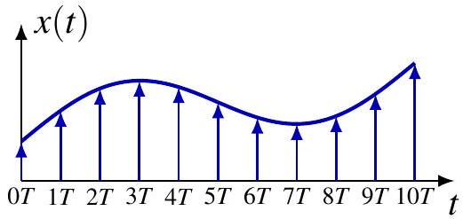

**离散时间信号**

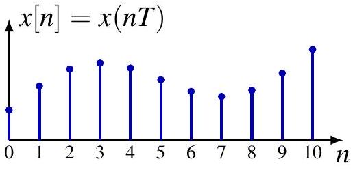

$T=$ 采样周期，均匀采样是最常见的方式。  
采样允许使用数字电子设备对连续时间信号进行处理、记录、传输、存储和检索。

- MP3、数字相机、打印机等应用

## 连续时间信号的采样

采样会丢失信息，不同信号可能产生相同的采样序列。

- $x_1(t)=\cos(\pi t/3)$ 与 $x_2(t)=\cos(7\pi t/3)$ 是不同的信号
- 但采样后得到完全相同的序列：$x_1[n]=\cos(\pi n/3)=x_2[n]=\cos(7\pi n/3)$

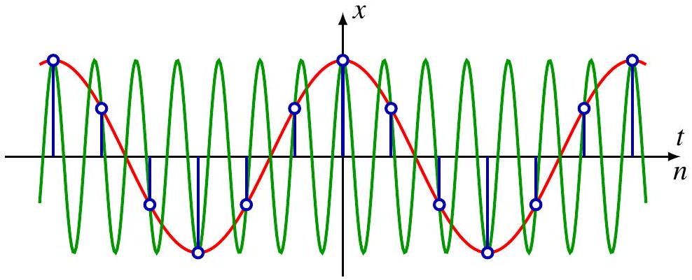

**关键问题**：在什么条件下可以从采样序列中无失真地恢复原始连续时间信号？

## 冲激列采样（时域）

**连续时间信号** $x(t)$

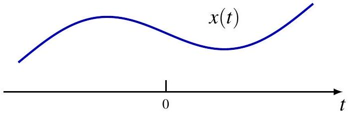

**冲激串**
$$p(t)=\sum_{n=-\infty}^{\infty} \delta(t-nT)$$

**采样信号**
$$x_p(t)=x(t)p(t)=\sum_{n=-\infty}^{\infty} x(nT)\delta(t-nT)$$

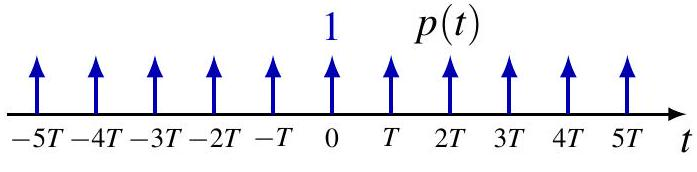

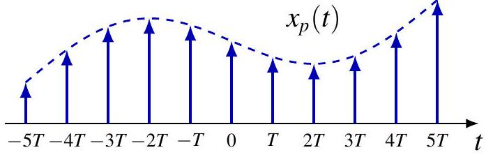

## 冲激列采样（频域）

**连续时间信号频谱** $X(j\omega)$

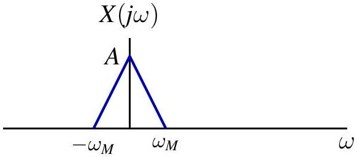

**冲激串频谱**
$$P(j\omega)=\omega_s \sum_{k=-\infty}^{\infty} \delta(\omega-k\omega_s)$$

**采样信号频谱**
$$X_p(j\omega)=\frac{1}{2\pi}(X*P)(\omega)=\frac{1}{T}\sum_{k=-\infty}^{\infty} X(j(\omega-k\omega_s))$$

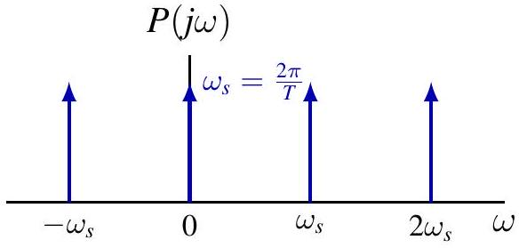

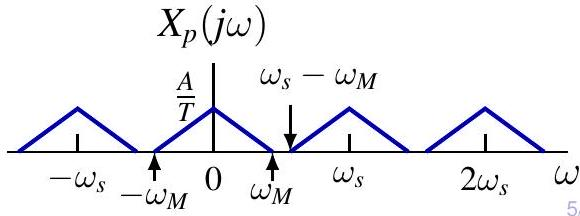

## 冲激列采样（频域）——带限信号

带限连续时间信号：$X(j\omega)=0$ 当 $|\omega|>\omega_M$ 时

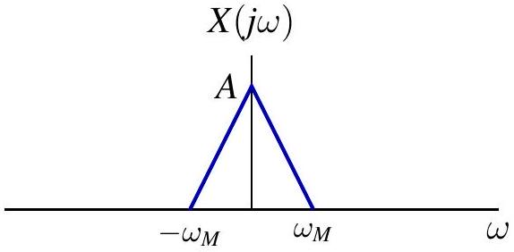

采样角频率 $\omega_s=2\pi/T$

**情况1**：$\omega_s > 2\omega_M$（频谱无重叠）——可以通过低通滤波恢复原始频谱

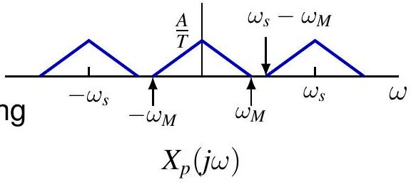

**情况2**：$\omega_s < 2\omega_M$（出现频谱重叠，即混叠）——无法恢复原始信号

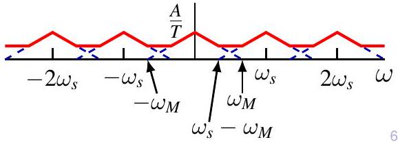

## 采样定理

若连续时间信号 $x(t)$ 是带限的（其频谱 $X(j\omega)=0$ 当 $|\omega|>\omega_M$），且采样满足

$$\omega_s \triangleq \frac{2\pi}{T} > 2\omega_M$$

（其中 $2\omega_M$ 称为**奈奎斯特率**），则该信号可由其采样序列 $x(nT),\ n\in\mathbb{Z}$ 唯一确定。

**重建步骤**： 1. 构造冲激采样信号 $x_p(t)=\sum_{n=-\infty}^{\infty} x(nT)\delta(t-nT)$ 2. 通过增益为 $T$、截止频率 $\omega_c\in(\omega_M, \omega_s-\omega_M)$ 的理想低通滤波器
$$H(j\omega)=T[u(\omega+\omega_c)-u(\omega-\omega_c)]$$
3. 滤波器输出 $x_r(t)$ 即为原始信号 $x(t)$

## 频域中的重建

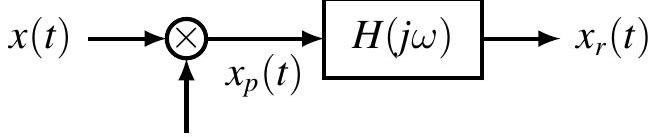

- 奈奎斯特频率：$\omega_M$
- 奈奎斯特率：$2\omega_M$
- 低通滤波器：增益 $T$，截止频率满足 $\omega_M < \omega_c < \omega_s - \omega_M$

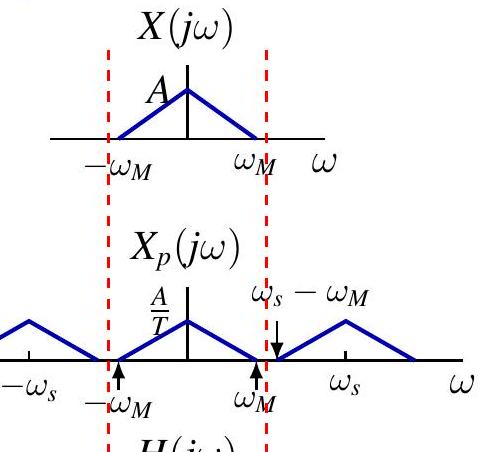

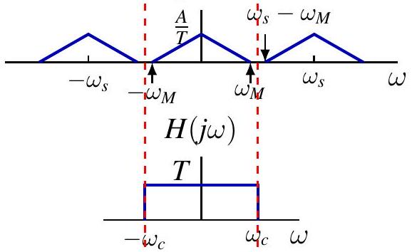

## 时域中的重建

低通滤波器的冲激响应：
$$h(t)=\frac{T\sin(\omega_c t)}{\pi t}$$

重建信号：
$$x_r(t)=\sum_{n=-\infty}^{\infty} x(nT)\frac{T\sin(\omega_c(t-nT))}{\pi(t-nT)}$$

## 时域中的重建（$\omega_c=\omega_s/2$）

当截止频率取 $\omega_c=\omega_s/2=\pi/T$ 时，得到 **Whittaker-Shannon 插值公式**：

$$x_r(t)=\sum_{n=-\infty}^{\infty} x(nT)\operatorname{sinc}\left(\frac{t-nT}{T}\right)$$

其中 $\operatorname{sinc}(t)=\frac{\sin(\pi t)}{\pi t}$

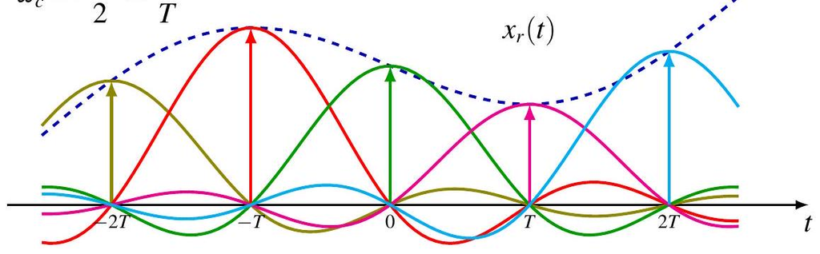

## 时域中的重建（其他截止频率示例）

$\omega_c=\omega_s/4=\pi/(2T) > \omega_M$

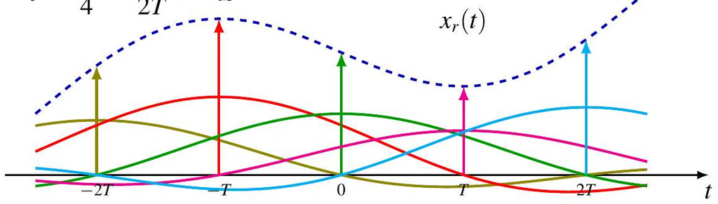

$\omega_c=3\omega_s/5 < \omega_s - \omega_M$

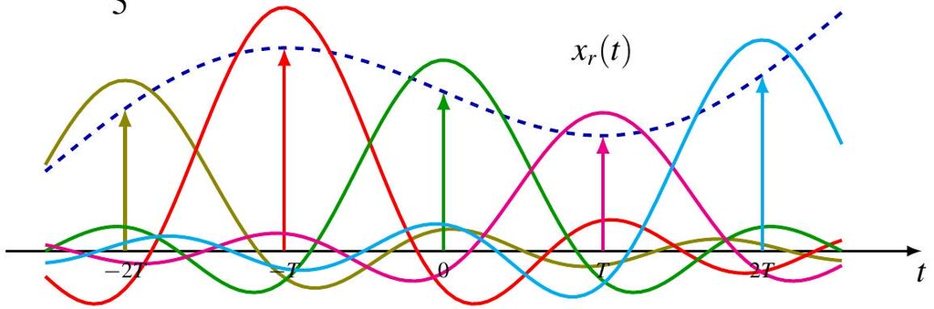

## 其他插值方法

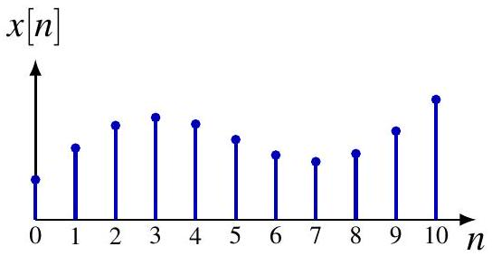

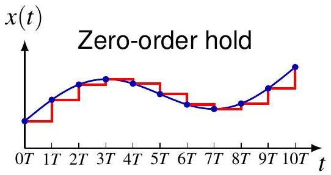

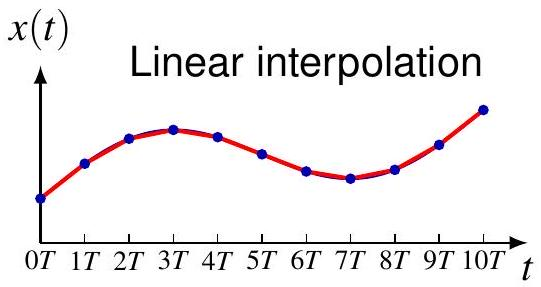

## 零阶保持（Zero-Order Hold）

重建信号：
$$x_0(t)=\sum_{n=-\infty}^{\infty} x(nT) h_0(t-nT)$$

零阶保持滤波器频率响应：
$$H_0(j\omega)=e^{-j\omega T/2} \frac{2\sin(\omega T/2)}{\omega}$$

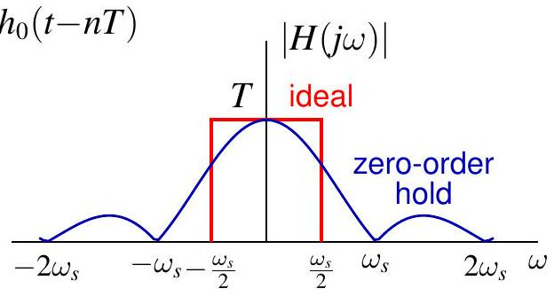

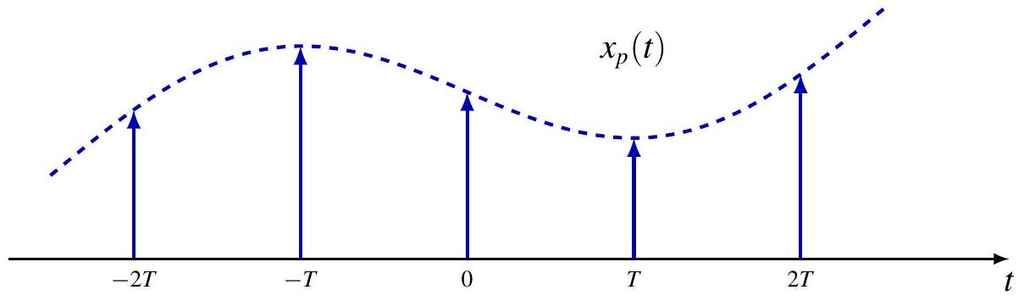

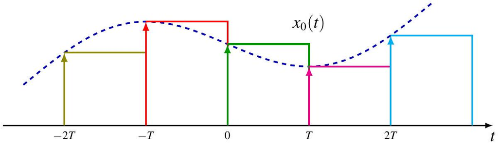

## 线性插值（First-Order Hold）

重建信号：
$$x_1(t)=\sum_{n=-\infty}^{\infty} x(nT) h_1(t-nT)$$

一阶保持滤波器频率响应：
$$H_1(j\omega)=\frac{1}{T}\left[\frac{\sin(\omega T/2)}{\omega/2}\right]^2$$

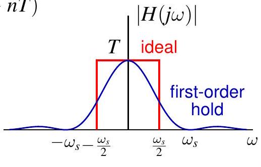

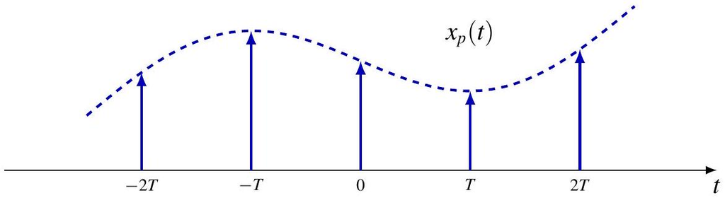

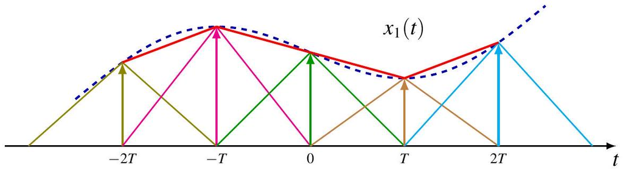